# Linear regression model to predict house prices in USA-notebook

### PROJECT NAME: A Linear Regression Model to Predict House Prices in the USA Using Machine Learning

### BY: Jacktone Etemesi

#### EMAIL: jacktoneetemesi1@gmail.com

*Introduction*

This notebook file contains the code for a linear regression model for predicting the price of houses in the USA based on the following attributes:

- Average income earned by people in the area
- Average age of houses in the area
- Average number of rooms in houses within the area
- Average number of bedrooms in houses within the area
- Population of the area.

Data Source

The data used in this analysis was collected and compiled by GANTALA SWETHA and can be found on this [Link:](https://www.kaggle.com/code/gantalaswetha/usa-housing-dataset-linear-regression)

### *1. Importing Data & Relevant Libraries*

```python
# importing relevant libraries
import numpy as np
import pandas as pd
import matplotlib.pyplot as plt
import seaborn as sns
%matplotlib inline
```

```python
# importing data

df=pd.read_csv('USA_Housing.csv')
```

## *2. Data Cleaning*

Under this section, we will take a peek into our dataset to understand it better. We will do this by exploring the following:

1. Variable names
2. Variables data types
3. Some descriptive statistics on numerical columns
4. Correlation between variables

```python
df.head()
```

|  | Avg. Area Income | Avg. Area House Age | Avg. Area Number of Rooms | Avg. Area Number of Bedrooms | Area Population | Price | Address |
| --- | --- | --- | --- | --- | --- | --- | --- |
| 0 | 79545.458574 | 5.682861 | 7.009188 | 4.09 | 23086.800503 | 1.059034e+06 | 208 Michael Ferry Apt. 674\nLaurabury, NE 3701... |
| 1 | 79248.642455 | 6.002900 | 6.730821 | 3.09 | 40173.072174 | 1.505891e+06 | 188 Johnson Views Suite 079\nLake Kathleen, CA... |
| 2 | 61287.067179 | 5.865890 | 8.512727 | 5.13 | 36882.159400 | 1.058988e+06 | 9127 Elizabeth Stravenue\nDanieltown, WI 06482... |
| 3 | 63345.240046 | 7.188236 | 5.586729 | 3.26 | 34310.242831 | 1.260617e+06 | USS Barnett\nFPO AP 44820 |
| 4 | 59982.197226 | 5.040555 | 7.839388 | 4.23 | 26354.109472 | 6.309435e+05 | USNS Raymond\nFPO AE 09386 |

```python
df.info()
```

```
<class 'pandas.core.frame.DataFrame'>
RangeIndex: 5000 entries, 0 to 4999
Data columns (total 7 columns):
 #   Column                        Non-Null Count  Dtype
---  ------                        --------------  -----
 0   Avg. Area Income              5000 non-null   float64
 1   Avg. Area House Age           5000 non-null   float64
 2   Avg. Area Number of Rooms     5000 non-null   float64
 3   Avg. Area Number of Bedrooms  5000 non-null   float64
 4   Area Population               5000 non-null   float64
 5   Price                         5000 non-null   float64
 6   Address                       5000 non-null   object
dtypes: float64(6), object(1)
memory usage: 273.6+ KB
```

```python
df.describe()
```

|  | Avg. Area Income | Avg. Area House Age | Avg. Area Number of Rooms | Avg. Area Number of Bedrooms | Area Population | Price |
| --- | --- | --- | --- | --- | --- | --- |
| count | 5000.000000 | 5000.000000 | 5000.000000 | 5000.000000 | 5000.000000 | 5.000000e+03 |
| mean | 68583.108984 | 5.977222 | 6.987792 | 3.981330 | 36163.516039 | 1.232073e+06 |
| std | 10657.991214 | 0.991456 | 1.005833 | 1.234137 | 9925.650114 | 3.531176e+05 |
| min | 17796.631190 | 2.644304 | 3.236194 | 2.000000 | 172.610686 | 1.593866e+04 |
| 25% | 61480.562388 | 5.322283 | 6.299250 | 3.140000 | 29403.928702 | 9.975771e+05 |
| 50% | 68804.286404 | 5.970429 | 7.002902 | 4.050000 | 36199.406689 | 1.232669e+06 |
| 75% | 75783.338666 | 6.650808 | 7.665871 | 4.490000 | 42861.290769 | 1.471210e+06 |
| max | 107701.748378 | 9.519088 | 10.759588 | 6.500000 | 69621.713378 | 2.469066e+06 |

```python
# checking for nulls
df.isnull().sum()
```

```
Avg. Area Income                0
Avg. Area House Age             0
Avg. Area Number of Rooms       0
Avg. Area Number of Bedrooms    0
Area Population                 0
Price                           0
Address                         0
dtype: int64
```

```python
#checking for duplicate values
df.duplicated().sum()
```

```
0
```

```python
# checking for Multicollinearity between our variables
df.corr(numeric_only=True)
```

|  | Avg. Area Income | Avg. Area House Age | Avg. Area Number of Rooms | Avg. Area Number of Bedrooms | Area Population | Price |
| --- | --- | --- | --- | --- | --- | --- |
| Avg. Area Income | 1.000000 | -0.002007 | -0.011032 | 0.019788 | -0.016234 | 0.639734 |
| Avg. Area House Age | -0.002007 | 1.000000 | -0.009428 | 0.006149 | -0.018743 | 0.452543 |
| Avg. Area Number of Rooms | -0.011032 | -0.009428 | 1.000000 | 0.462695 | 0.002040 | 0.335664 |
| Avg. Area Number of Bedrooms | 0.019788 | 0.006149 | 0.462695 | 1.000000 | -0.022168 | 0.171071 |
| Area Population | -0.016234 | -0.018743 | 0.002040 | -0.022168 | 1.000000 | 0.408556 |
| Price | 0.639734 | 0.452543 | 0.335664 | 0.171071 | 0.408556 | 1.000000 |

### *3. Exploratory Data Analysis*

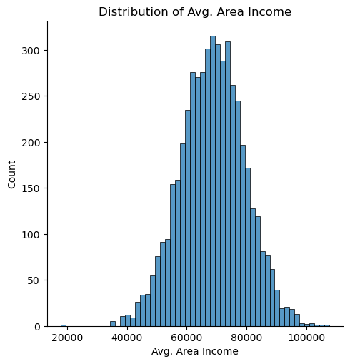

```python
sns.displot(data=df,x='Avg. Area Income',label=True).set(title='Distribution of Avg. Area Income')
```

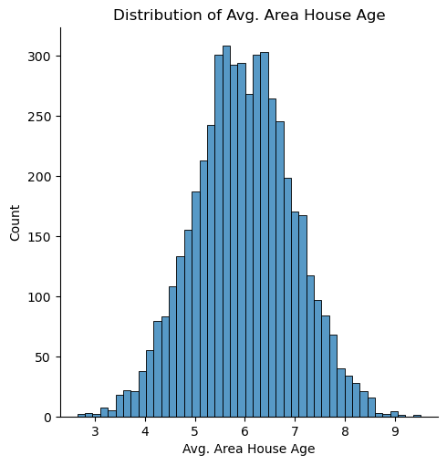

```python
sns.displot(data=df,x='Avg. Area House Age').set(title='Distribution of Avg. Area House Age')
```

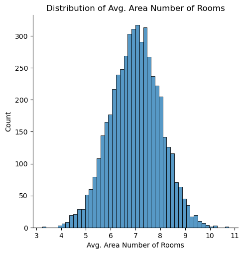

```python
sns.displot(data=df,x='Avg. Area Number of Rooms').set(title='Distribution of Avg. Area Number of Rooms')
```

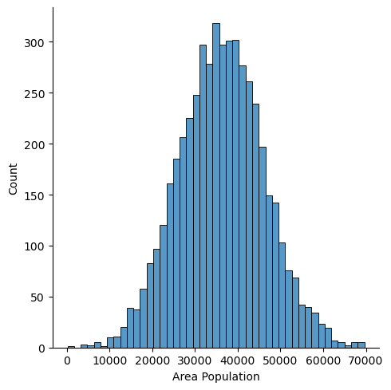

```python
sns.displot(data=df,x='Area Population')
```

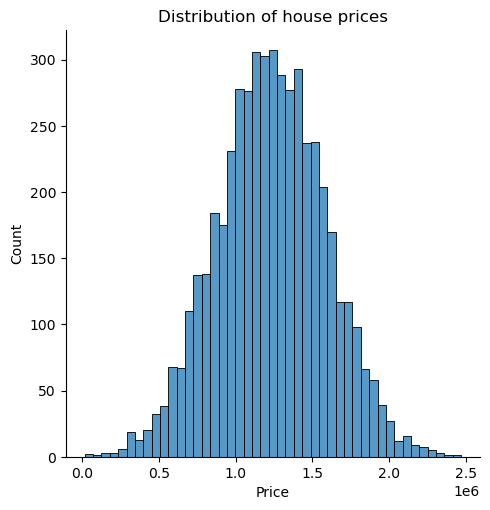

```python
sns.displot(data=df,x='Price').set(title='Distribution of house prices')
```

```python
# checking for Multicollinearity between our variables
df.corr(numeric_only=True)
```

|  | Avg. Area Income | Avg. Area House Age | Avg. Area Number of Rooms | Avg. Area Number of Bedrooms | Area Population | Price |
| --- | --- | --- | --- | --- | --- | --- |
| Avg. Area Income | 1.000000 | -0.002007 | -0.011032 | 0.019788 | -0.016234 | 0.639734 |
| Avg. Area House Age | -0.002007 | 1.000000 | -0.009428 | 0.006149 | -0.018743 | 0.452543 |
| Avg. Area Number of Rooms | -0.011032 | -0.009428 | 1.000000 | 0.462695 | 0.002040 | 0.335664 |
| Avg. Area Number of Bedrooms | 0.019788 | 0.006149 | 0.462695 | 1.000000 | -0.022168 | 0.171071 |
| Area Population | -0.016234 | -0.018743 | 0.002040 | -0.022168 | 1.000000 | 0.408556 |
| Price | 0.639734 | 0.452543 | 0.335664 | 0.171071 | 0.408556 | 1.000000 |

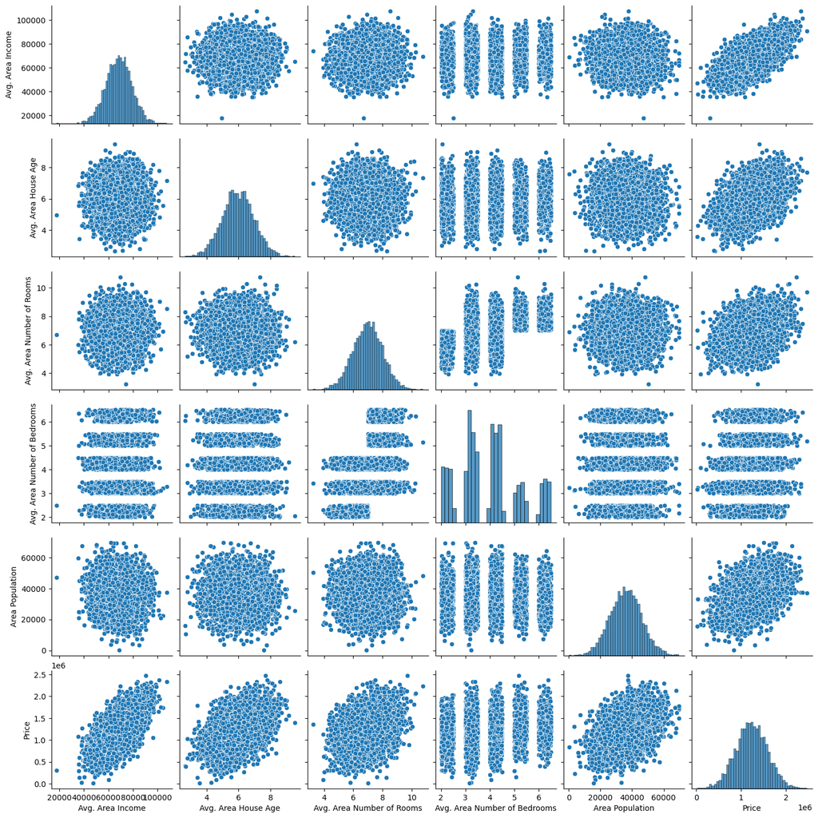

```python
# visualizing the correlation
sns.pairplot(df)
```

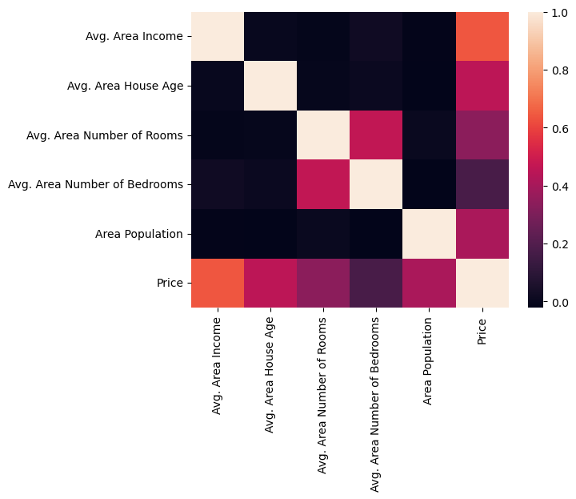

```python
sns.heatmap(df.corr(numeric_only=True))
```

### *4. Fitting and Training our model*

```python
# defining dependent and independent variables

x=df[df.columns[:-2]]
y=df['Price']
```

```python
# splitting data into train an test data
from sklearn.model_selection import train_test_split

x_train,x_test,y_train,y_test=train_test_split(x,y,train_size=0.70,random_state=101)
```

```python
# fitting data

from sklearn.linear_model import LinearRegression

lmodel=LinearRegression()

lmodel.fit(X=x_train,y=y_train)
```

```
LinearRegression()
```

```python
# training our model

predictions=lmodel.predict(x_test)
```

```python
# Evaluating Model performance

from sklearn import metrics

mae=round(metrics.mean_absolute_error(y_test,predictions),3)
mse=round(metrics.mean_squared_error(y_test,predictions),3)
mrte=round(np.sqrt(mse),3)
r_value=round(metrics.explained_variance_score(y_test,predictions),3)
#print(f"Mean Absolute Error:Mean Squared Error: {}\nMean Square Root Error: {}\nr statistic: {}".format(mae,mse,mrte,r_value))

print(f'Mean Absolute Error: {mae}\nMean Squared Error: {mse}\nMean Square Root Error: {mrte}\nr statistic: {r_value}')
```

```
Mean Absolute Error: 81257.558
Mean Squared Error: 10169125565.897
Mean Square Root Error: 100842.082
r statistic: 0.919
```

*Loss functions are used to evaluate the performance of our predictive model by measuring the discrepancy between our predicted values and the actual values. Let's explain the following loss functions of our model:*

1. Mean Absolute Error (MAE):
   - The Mean Absolute Error measures the average absolute difference between our predicted values and the actual values.
   - In our model, the MAE is 81257.558. On average, our predicted house prices deviate from the actual prices by approximately $81,257.558.
2. Mean Squared Error (MSE):
   - The Mean Squared Error measures the average squared difference between our predicted values and the actual values.
   - In our model, the MSE is 10169125565.897. On average, our predicted house prices deviate from the actual prices by approximately $10,169,125,565.897 (squared).
3. Mean Square Root Error (MRTE):
   - The Mean Square Root Error is the square root of the Mean Squared Error. It provides a more interpretable measure of error compared to MSE.
   - In our model, the MRTE is 100842.082. On average, our predicted house prices deviate from the actual prices by approximately $100,842.082.
4. r statistic:
   - The r statistic represents the correlation coefficient or the coefficient of determination (R-squared).
   - In our model, the r statistic is 0.919. This indicates a strong positive correlation between our predicted house prices and the actual prices. Approximately 91.9% of the variability in the house prices can be explained by our model.

```python
# formulating coefficient matrix

coeff=lmodel.coef_

intercept=lmodel.intercept_

coeff_matrix=pd.DataFrame(data=coeff,index=df.columns[0:-2],columns=['Coefficients'])
coeff_matrix
```

|  | Coefficients |
| --- | --- |
| Avg. Area Income | 21.617635 |
| Avg. Area House Age | 165221.119872 |
| Avg. Area Number of Rooms | 121405.376596 |
| Avg. Area Number of Bedrooms | 1318.718783 |
| Area Population | 15.225196 |

#### *Our Model's coefficients can be explained as follows:*

1. Avg. Area Income:
   - The coefficient for Avg. Area Income is 21.617635. This means that, on average, a one-unit increase in the average area income is associated with an increase of $21.617635 in the predicted house price, holding other variables constant.
2. Avg. Area House Age:
   - The coefficient for Avg. Area House Age is 165221.119872. This indicates that, on average, a one-unit increase in the average area house age is associated with an increase of $165,221.119872 in the predicted house price, holding other variables constant.
3. Avg. Area Number of Rooms:
   - The coefficient for Avg. Area Number of Rooms is 121405.376596. This suggests that, on average, a one-unit increase in the average number of rooms in houses within the area is associated with an increase of $121,405.376596 in the predicted house price, holding other variables constant.
4. Avg. Area Number of Bedrooms:
   - The coefficient for Avg. Area Number of Bedrooms is 1318.718783. This indicates that, on average, a one-unit increase in the average number of bedrooms in houses within the area is associated with an increase of $1,318.718783 in the predicted house price, holding other variables constant.
5. Area Population:
   - The coefficient for Area Population is 15.225196. This suggests that, on average, a one-unit increase in the area population is associated with an increase of $15.225196 in the predicted house price, holding other variables constant.

These coefficients provide insights into the relationships between the predictor variables and the predicted house prices in our model.

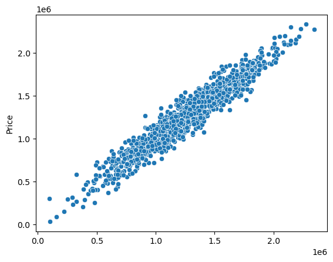

```python
sns.scatterplot(x=predictions,y=y_test)
```

*We observe a strong correlation between our predicted and observed Y values, indicating that our model has a high confidence interval. This suggests that our model is effectively capturing the relationship between the predictor variables and the target variable, leading to accurate predictions.*

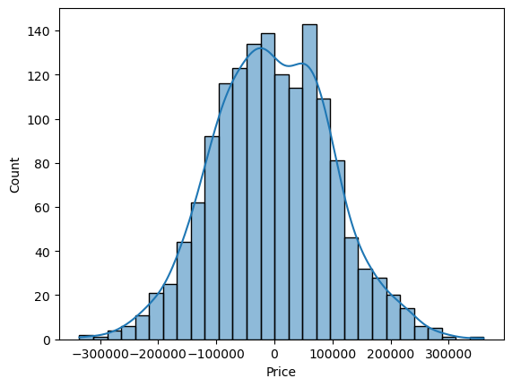

```python
# plotting for distribution of residuals

sns.histplot(y_test-predictions,kde=True)
```

*The residuals, which represent the difference between the observed and predicted y values, exhibit a normal distribution. This suggests that our model is well balanced and adequately captures the underlying patterns in the data. The coefficients of our model are as follows:*

```python
coeff_matrix
```

|  | Coefficients |
| --- | --- |
| Avg. Area Income | 21.617635 |
| Avg. Area House Age | 165221.119872 |
| Avg. Area Number of Rooms | 121405.376596 |
| Avg. Area Number of Bedrooms | 1318.718783 |
| Area Population | 15.225196 |

*From the coefficient matrix above, it is observed that Avg.Area house age greatly contributes to the price of a house followed by the number of rooms. By assigning these coefficients alphabet characters a, b, c, d, e, we get the following coefficient matrix :*

```python
symbols='a b c d e'.split(' ')
coeff_matrix['symbol']=symbols
coeff_matrix
```

|  | Coefficients | symbol |
| --- | --- | --- |
| Avg. Area Income | 21.617635 | a |
| Avg. Area House Age | 165221.119872 | b |
| Avg. Area Number of Rooms | 121405.376596 | c |
| Avg. Area Number of Bedrooms | 1318.718783 | d |
| Area Population | 15.225196 | e |